# Regression

## Linear Regression

- Regression is a method for modeling the effect of one or more predictors (independent variables) on an outcome (dependent variable)
- Linear regression is the typically used when the dependent variable is continuous (or at least approximately continuous)

## Linear Regression

$$\begin{align*}
y_i =& \beta_0 + \beta_1x_{1i} + \beta_2x_2{_i} + \beta_3x_3{_i} ... + e_i\\
y_i &= \text{The dependent variable}\\
\beta_0 &=\text{Intercept or Constant: the expected value of } y_i \text{when all the X values = 0}\\
\beta_1...\beta_k &= \text{Coefficient: the effect of a one unit increase in predictor } x_k \text{ on expected y}\\
e_i &= \text{Error or Residual: the difference between the prediction for } y_i \text{ and its actual value}
\end{align*}$$

## Linear Regression

In its simplest form, you can think of a linear regression as an estimate of the line through X (an independent variable) and Y (an outcome) that minimizes the sum of squared errors (the squared distance between the line and each point)

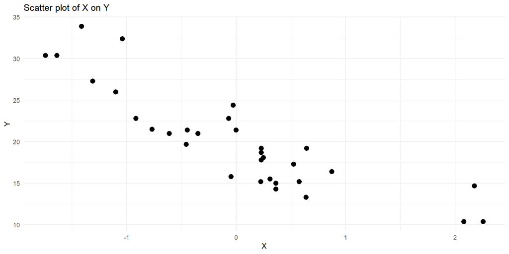

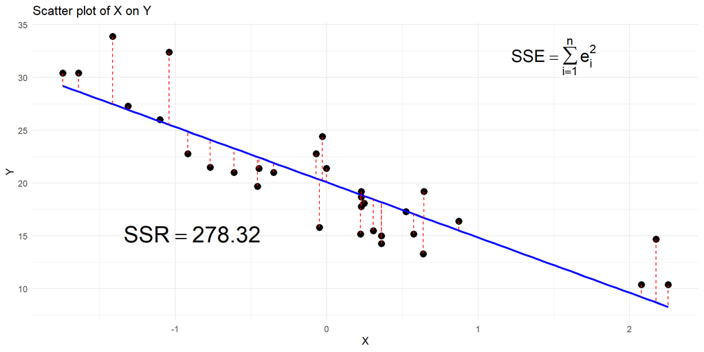

## Linear Regression

The slope of this line (denoted with the symbol $\beta_1$) interpreted as the effect of a one unit increase on X on the expected value of Y.

[figure not shown]

## Linear Regression

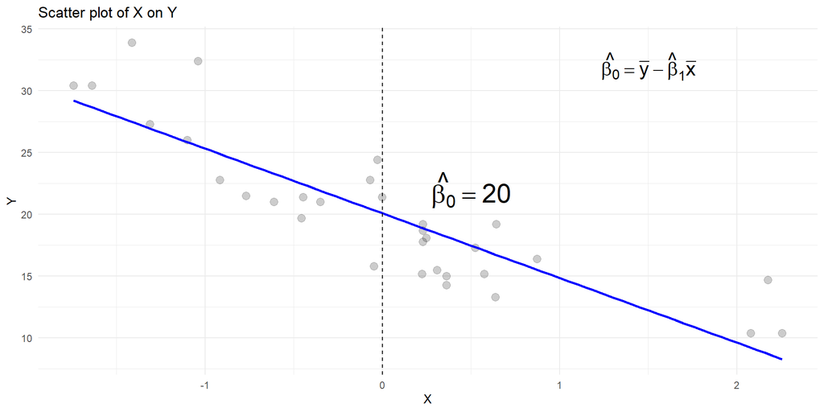

## Linear Regression

The variance of the regression ($\sigma^2_e$) is based on the average error across the entire regression line:

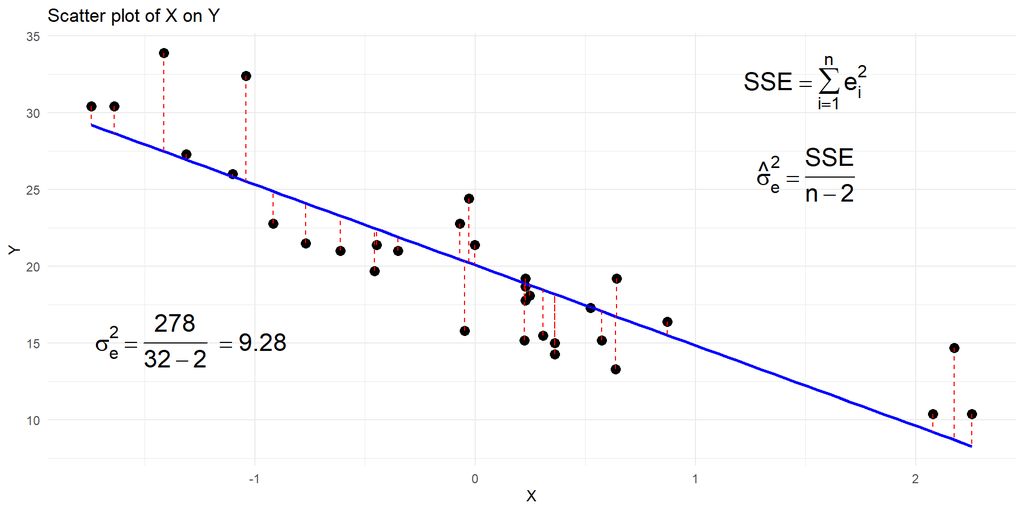

## Linear Regression

And the $\sigma^2_e$ can be used as part of the equation for calculating the standard error around the regression line:

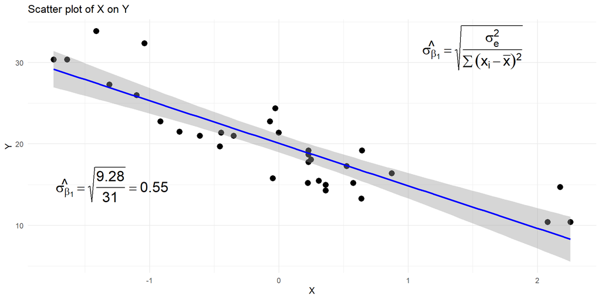

## Linear Regression

The squared residuals can also be used to get a summary measure of the overall fit of the model called $R^2$, which represents the proportion of variance in the dependent variable explained by the model.

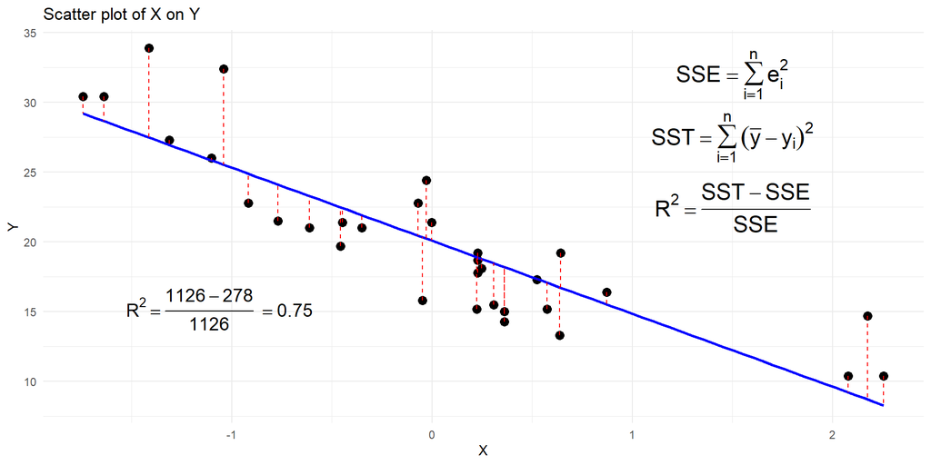

## Regression with one predictor

```r
data<-readRDS(url('https://github.com/Neilblund/SDSB340-Fall-2026/raw/refs/heads/master/Data/lm_data.rds'))
model<-lm(y ~ x, data = data)
summary(model)
```

```
Call:
lm(formula = y ~ x, data = data)

Residuals:
    Min      1Q  Median      3Q     Max
-4.5432 -2.3647 -0.1252  1.4096  6.8727

Coefficients:
            Estimate Std. Error t value Pr(>|t|)
(Intercept)  20.0906     0.5384  37.313  < 2e-16 ***
x            -5.2293     0.5471  -9.559 1.29e-10 ***
---
Signif. codes:  0 '***' 0.001 '**' 0.01 '*' 0.05 '.' 0.1 ' ' 1

Residual standard error: 3.046 on 30 degrees of freedom
Multiple R-squared:  0.7528,    Adjusted R-squared:  0.7446
F-statistic: 91.38 on 1 and 30 DF,  p-value: 1.294e-10
```

## Regression with one predictor

- We’ll try looking at a real life example using data from the American Time Use Survey (ATUS), which measures the amount of time people spend doing various activities such as working, attending school, caring for children etc.
- For this regression, we’ll look at the effect of age on the amount of time spent doing leisure activities (socializing, sports, games, etc.)

## Regression with one predictor

In R, you can use the `lm` function to make a linear model. Then write the name of the dependent variable followed by a `~` and then one or more predictors:

```r
library(tidyverse)
library(modelsummary)
filloc<-url('https://github.com/Neilblund/SDSB340-Fall-2026/raw/refs/heads/master/Data/atus25_subset.rds')
atus<-readRDS(filloc)
model1<-lm(leisure ~ age, data=atus)
summary(model1)
```

```
Call:
lm(formula = leisure ~ age, data = atus)

Residuals:
    Min      1Q  Median      3Q     Max
-448.53 -165.94  -29.24  142.09  874.07

Coefficients:
            Estimate Std. Error t value Pr(>|t|)
(Intercept) 171.4700     8.4236   20.36   <2e-16 ***
age           3.2595     0.1494   21.82   <2e-16 ***
---
Signif. codes:  0 '***' 0.001 '**' 0.01 '*' 0.05 '.' 0.1 ' ' 1

Residual standard error: 217.5 on 6144 degrees of freedom
Multiple R-squared:  0.07195,   Adjusted R-squared:  0.0718
F-statistic: 476.3 on 1 and 6144 DF,  p-value: < 2.2e-16
```

## Regression with one predictor

- At age 0, we expect an average person would spend 171 minutes on leisure activities in a day (note that this isn’t meaningful! No infants responded to the survey)
- Every additional year older is associated with an additional 3.26 minutes of leisure time (95% CI: 2.97 - 3.56)
- Variation in age explains around 7% of the variation in leisure time.

**DV: Minutes spent on leisure activities**

|  | (1) |
| --- | --- |
| (Intercept) | 171 |
|  | [155, 188] |
| Age (years) | 3 |
|  | [3, 4] |
| Num.Obs. | 6146 |
| R2 | 0.072 |
| R2 Adj. | 0.072 |

## Regression with one predictor

What is the model’s predicted leisure time for a 30 year old?

$\operatorname{leisure} = \beta_{0} + \beta_{1}(\operatorname{age}) + \epsilon$

$\operatorname{\widehat{leisure}} = 171.5 + 3.3(\operatorname{30}) = 269.3$

**DV: Minutes spent on leisure activities**

|  | (1) |
| --- | --- |
| (Intercept) | 171.5 |
|  | [155.0, 188.0] |
| Age (years) | 3.3 |
|  | [3.0, 3.6] |
| Num.Obs. | 6146 |
| R2 | 0.072 |
| R2 Adj. | 0.072 |

## Regression with multiple predictors

- Regression models allow us to include multiple predictors.
- When including additional variables in a model, the coefficient values should be interpreted as the average effect of a one unit increase in x while controlling for the remaining covariates.

## Regression with multiple predictors

One way to think of this is as a regression that estimates the effect of one predictor after removing any variance that is associated with the predictors.

$$\begin{align*}
y =& \beta_0 + \beta X + e\\
&\beta_0 + \beta X = \text{the part of } y \text{ that's explained by } X\\
&e = \text{part of y that can't be explained by } X
\end{align*}$$

## Regression with multiple predictors

1. Regress $y \sim x_2$ and store the residuals $\color{Magenta}{(e_y|x_2)}$
2. Regress $x_1 \sim x_2$ and store the residuals $\color{Orange}{(e_{x1}|x_2)}$
3. Regress $\color{Magenta}{(e_y|x_2)} \sim \color{Orange}{(e_{x1}|x_2)}$ (with no intercept term) to get the effect of $x_1$ while holding constant for $x_2$

this is not really how things work computationally, but it’s mathematically equivalent.

### Intuition

$$\color{Magenta}{(e_y|x_2)}$$

```r
m0<-lm(Y ~ X2, data=df)
ey_x2 <- df$Y - predict(m0)
```

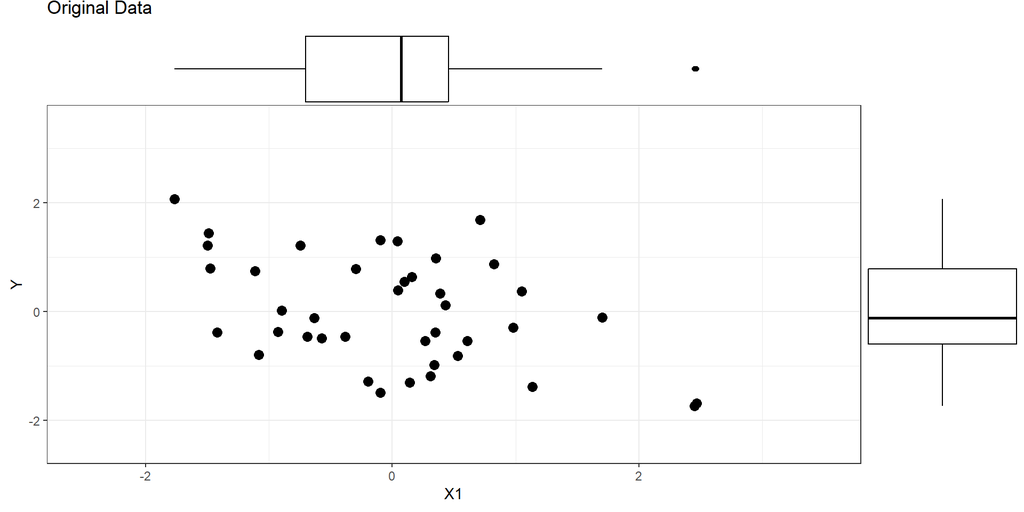

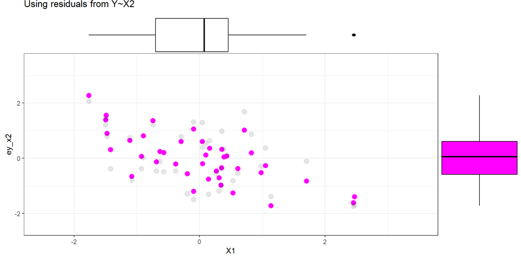

### Intuition

$$\color{Orange}{(e_{x1}|x_2)}$$

```r
m1<-lm(X1 ~ X2, data=df)
ex1_x2 <- df$X1 - predict(m1)
```

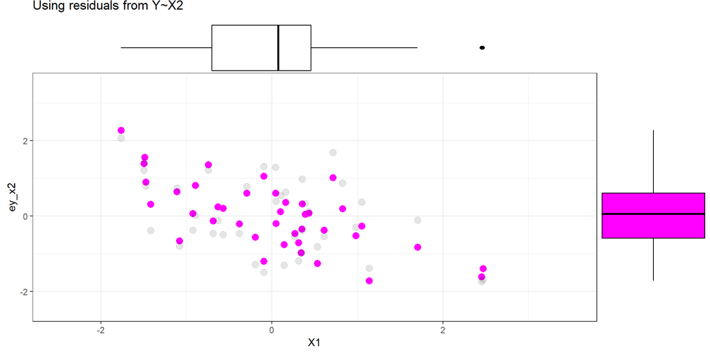

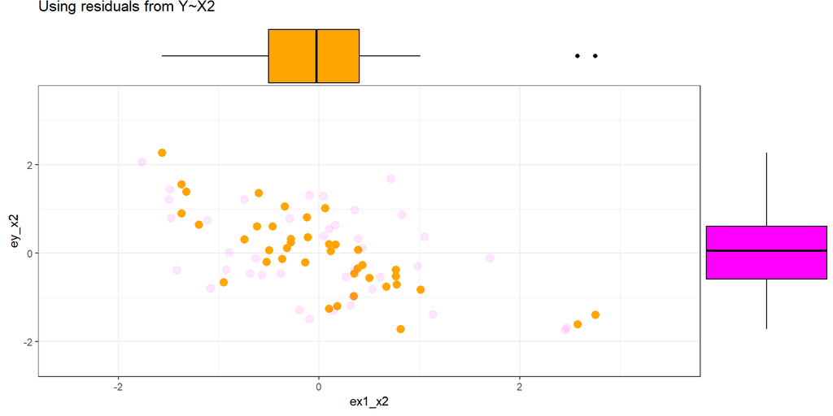

### Intuition

$\color{Magenta}{(e_y|x_2)} \sim \color{Orange}{(e_{x1}|x_2)}$

```r
m2<-lm(ey_x2 ~ 0 + ex1_x2, data=df)
```

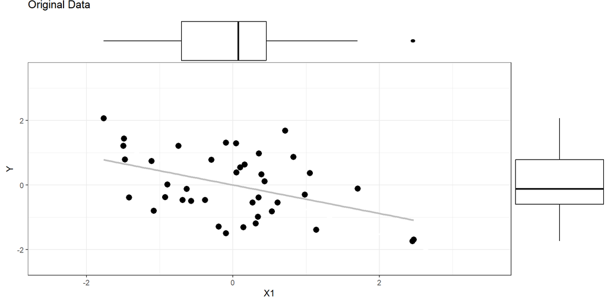

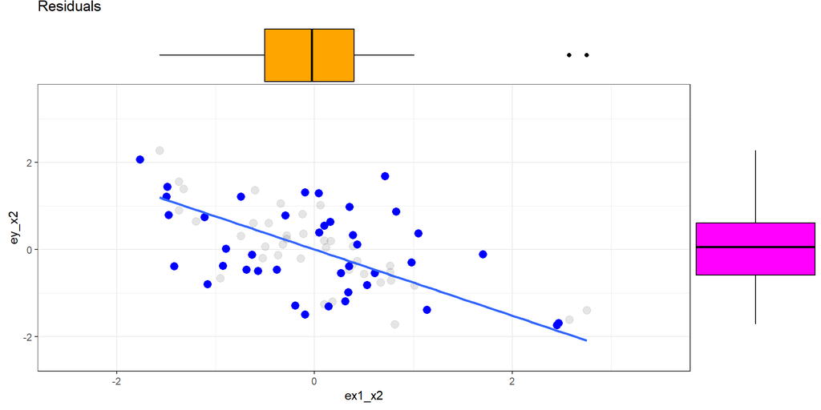

### Intuition

Note that the coefficient for X1 is identical here:

**See code for generating simulated data**

```r
set.seed(1000)
n <- 40
R <- matrix(c(1, 0.5,
              0.5, 1),
            nrow = 2, ncol = 2, byrow = TRUE)

beta<-c(1, -1.5, 2)
mu <- c(X1 = 0, X2 = 0)
X<-cbind(1, mvtnorm::rmvnorm(n, mean = mu, sigma = R))
Y<-X%*%beta + rnorm(n)
df<-data.frame(Y, X)
```

```r
ey_x2<-df$Y - predict(lm(Y~X2, data=df))
ex1_x2  <- df$X1 - predict(lm(X1 ~ X2, data=df))
lm(ey_x2 ~ 0 + ex1_x2)
```

```
Call:
lm(formula = ey_x2 ~ 0 + ex1_x2)

Coefficients:
ex1_x2
-1.374
```

```r
lm(Y ~ X1 +X2, data=df)
```

```
Call:
lm(formula = Y ~ X1 + X2, data = df)

Coefficients:
(Intercept)           X1           X2
      1.237       -1.374        1.582
```

### Key points

Multiple regression coefficients can be interpreted as the expected change in y for each one unit change in x holding constant for the other predictors.

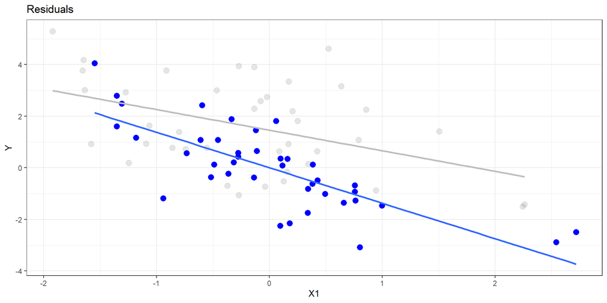

### Key points

Adding an additional predictor (X2) can substantially change the estimated effect of another predictor (X1) if X2 is correlated with both X1 and Y

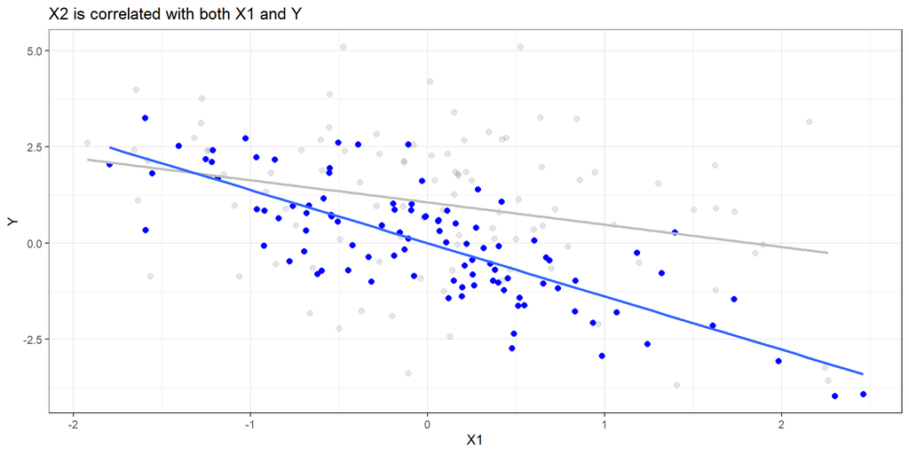

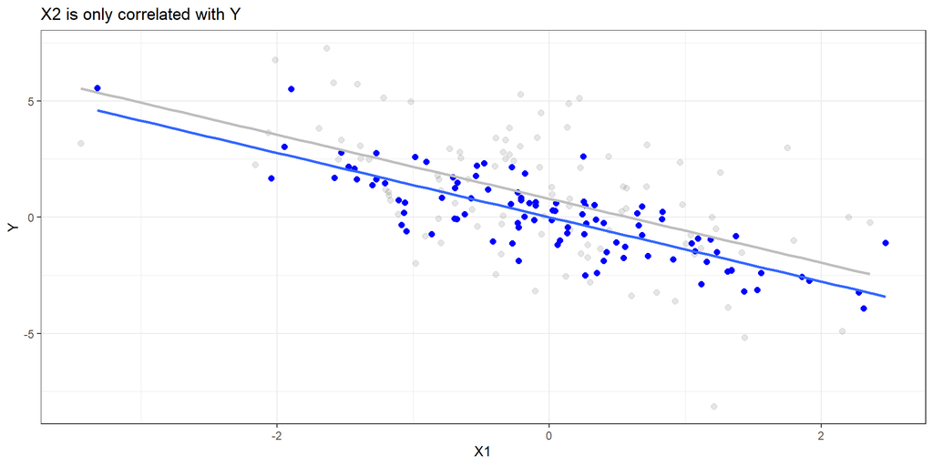

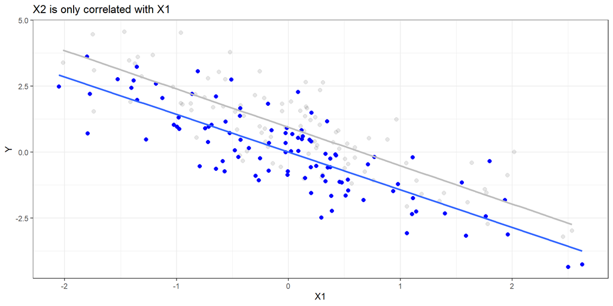

### Key points

Controlling for additional predictors means we lose some of the variability in the data, so adding too many predictors (or just a few strongly correlated predictors) can leave us without enough variability to estimate anything.

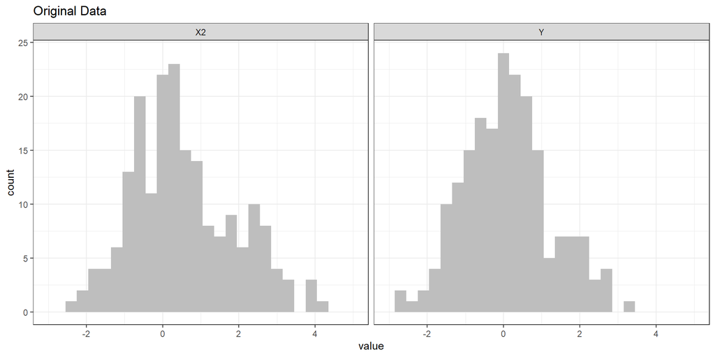

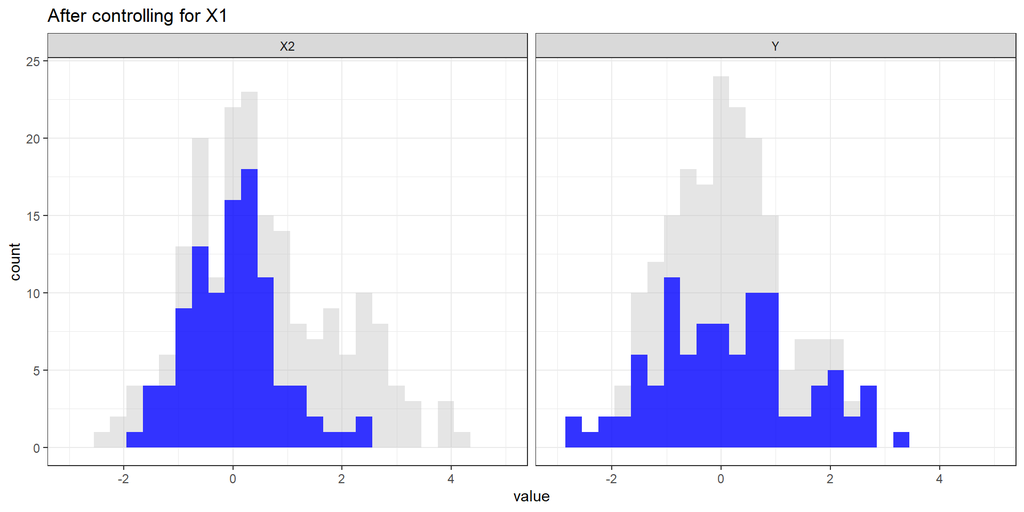

## Regression with multiple predictors

Going back to the original model, let’s see what happens when we control for number of household children?

```r
model2<-lm(leisure ~ age + num_children, data=atus)
summary(model2)
```

```
Call:
lm(formula = leisure ~ age + num_children, data = atus)

Residuals:
    Min      1Q  Median      3Q     Max
-442.85 -164.83  -27.58  141.43  873.38

Coefficients:
             Estimate Std. Error t value Pr(>|t|)
(Intercept)  219.9058     9.9459  22.110   <2e-16 ***
age            2.6229     0.1643  15.961   <2e-16 ***
num_children -28.8973     3.2061  -9.013   <2e-16 ***
---
Signif. codes:  0 '***' 0.001 '**' 0.01 '*' 0.05 '.' 0.1 ' ' 1

Residual standard error: 216.1 on 6143 degrees of freedom
Multiple R-squared:  0.08406,   Adjusted R-squared:  0.08376
F-statistic: 281.9 on 2 and 6143 DF,  p-value: < 2.2e-16
```

## Regression with multiple predictors

- Notice that this *slightly* changes the coefficient on age.
- You might also notice a slight jump in the R-squared value, because our more complex model also explains more variation.

**DV: Minutes spent on leisure activities**

|  | Model 1 | Model 2 |
| --- | --- | --- |
| (Intercept) | 171.5 | 219.9 |
|  | [155.0, 188.0] | [200.4, 239.4] |
| Age (years) | 3.3 | 2.6 |
|  | [3.0, 3.6] | [2.3, 2.9] |
| Number of household children < 18; |  | -28.9 |
|  |  | [-35.2, -22.6] |
| Num.Obs. | 6146 | 6146 |
| R2 | 0.072 | 0.084 |
| R2 Adj. | 0.072 | 0.084 |

## Regression with multiple predictors

What’s the predicted leisure time for a 30 year old with one child under model 2?

$\operatorname{leisure} = \beta_{0} + \beta_{1}(\operatorname{age}) + \beta_{2}(\operatorname{num\_children}) + \epsilon$

$\operatorname{\widehat{leisure}} = 219.9 + 2.6(30) - 28.9(1) = 269$

**DV: Minutes spent on leisure activities**

|  | Model 1 | Model 2 |
| --- | --- | --- |
| (Intercept) | 171.5 | 219.9 |
|  | [155.0, 188.0] | [200.4, 239.4] |
| Age (years) | 3.3 | 2.6 |
|  | [3.0, 3.6] | [2.3, 2.9] |
| Number of household children < 18; |  | -28.9 |
|  |  | [-35.2, -22.6] |
| Num.Obs. | 6146 | 6146 |
| R2 | 0.072 | 0.084 |
| R2 Adj. | 0.072 | 0.084 |

## Regression with categorical predictors

- In some cases, regression models might include one or more categorical predictor variables.
- For instance, I might want to include employment status as an additional predictor for leisure time.

## Regression with categorical predictors

In order to make a categorical variable interpretable in a regression model, we need to “dummy-code” it

| leisure | age | num_children | employment_status |
| --- | --- | --- | --- |
| 30 | 55 | 0 | Employed |
| 83 | 24 | 0 | Employed |
| 270 | 58 | 0 | Not in labor force |
| 290 | 80 | 0 | Not in labor force |
| 0 | 46 | 0 | Unemployed |
| 210 | 16 | 3 | Unemployed |

## Regression with categorical predictors

We would then include all but one column as separate predictors for the model. Coefficient values would then be interpreted as the expected difference for someone moving from the excluded category to the category for that coefficient.

| age | Employed | Not in labor force | Unemployed |
| --- | --- | --- | --- |
| 55 | 1 | 0 | 0 |
| 24 | 1 | 0 | 0 |
| 58 | 0 | 1 | 0 |
| 80 | 0 | 1 | 0 |
| 46 | 0 | 0 | 1 |
| 16 | 0 | 0 | 1 |

## Regression with categorical predictors

R performs this automatically if we include a non-numeric variable as a predictor in our model:

```r
model3<-lm(leisure ~ age + num_children + employment_status, data=atus)
summary(model3)
```

```
Call:
lm(formula = leisure ~ age + num_children + employment_status,
    data = atus)

Residuals:
    Min      1Q  Median      3Q     Max
-462.87 -157.12  -28.29  129.70  836.86

Coefficients:
                                    Estimate Std. Error t value Pr(>|t|)
(Intercept)                         253.8267     9.8859  25.676  < 2e-16 ***
age                                   0.9729     0.1808   5.382 7.66e-08 ***
num_children                        -30.7069     3.1065  -9.885  < 2e-16 ***
employment_statusNot in labor force 126.3534     6.3126  20.016  < 2e-16 ***
employment_statusUnemployed          80.4791    15.8960   5.063 4.25e-07 ***
---
Signif. codes:  0 '***' 0.001 '**' 0.01 '*' 0.05 '.' 0.1 ' ' 1

Residual standard error: 209.3 on 6141 degrees of freedom
Multiple R-squared:  0.1413,    Adjusted R-squared:  0.1407
F-statistic: 252.6 on 4 and 6141 DF,  p-value: < 2.2e-16
```

## Regression with categorical predictors

**DV: Minutes spent on leisure activities**

|  | Model 1 | Model 2 | Model 3 |
| --- | --- | --- | --- |
| (Intercept) | 171.5 | 219.9 | 253.8 |
|  | [155.0, 188.0] | [200.4, 239.4] | [234.4, 273.2] |
| Age (years) | 3.3 | 2.6 | 1.0 |
|  | [3.0, 3.6] | [2.3, 2.9] | [0.6, 1.3] |
| Number of household children < 18; |  | -28.9 | -30.7 |
|  |  | [-35.2, -22.6] | [-36.8, -24.6] |
| employment_status [Employed] |  |  | - |
| employment_status [Not in labor force] |  |  | 126.4 |
|  |  |  | [114.0, 138.7] |
| employment_status [Unemployed] |  |  | 80.5 |
|  |  |  | [49.3, 111.6] |
| Num.Obs. | 6146 | 6146 | 6146 |
| R2 | 0.072 | 0.084 | 0.141 |
| R2 Adj. | 0.072 | 0.084 | 0.141 |

## Regression with categorical predictors

What’s the expected leisure time for an unemployed 30 year old with one child?

$$\begin{aligned}
\operatorname{leisure} &= \beta_{0}\ + \\
&\quad \beta_{1}(\operatorname{age})\ + \\
&\quad \beta_{2}(\operatorname{num\_children})\ + \\
&\quad \beta_{3}(\operatorname{employment\_status}_{\operatorname{Not\ in\ labor\ force}})\ + \\
&\quad \beta_{4}(\operatorname{employment\_status}_{\operatorname{Unemployed}})\ + \\
&\quad \epsilon
\end{aligned}$$

**DV: Minutes spent on leisure activities**

|  | Model 3 |
| --- | --- |
| (Intercept) | 253.8 |
|  | [234.4, 273.2] |
| Age (years) | 1.0 |
|  | [0.6, 1.3] |
| Number of household children < 18; | -30.7 |
|  | [-36.8, -24.6] |
| employment_status [Employed] | - |
| employment_status [Not in labor force] | 126.4 |
|  | [114.0, 138.7] |
| employment_status [Unemployed] | 80.5 |
|  | [49.3, 111.6] |
| Num.Obs. | 6146 |
| R2 | 0.141 |
| R2 Adj. | 0.141 |

## Regression with categorical predictors

What’s the expected leisure time for an unemployed 30 year old with one child?

$$\begin{aligned}
\operatorname{\widehat{leisure}} &= 253.8\ + \\
&\quad 1(\operatorname{age = 30})\ - \\
&\quad 30.7(\operatorname{num\_children = 1})\ + \\
&\quad 126.4(\operatorname{employment}_{\operatorname{Not\ in\ labor\ force}}=0)\ + \\
&\quad 80.5(\operatorname{employment}_{\operatorname{Unemployed}}=1)
\end{aligned}$$

$$= 333.6$$

**DV: Minutes spent on leisure activities**

|  | Model 3 |
| --- | --- |
| (Intercept) | 253.8 |
|  | [234.4, 273.2] |
| Age (years) | 1.0 |
|  | [0.6, 1.3] |
| Number of household children < 18; | -30.7 |
|  | [-36.8, -24.6] |
| employment_status [Employed] | - |
| employment_status [Not in labor force] | 126.4 |
|  | [114.0, 138.7] |
| employment_status [Unemployed] | 80.5 |
|  | [49.3, 111.6] |
| Num.Obs. | 6146 |
| R2 | 0.141 |
| R2 Adj. | 0.141 |

## Changing the reference category

Note that we can modify the reference category here to change the excluded variable. This is effectively the same model, but it may slightly change how you interpret results:

```r
atus$employment_status_relevel<- relevel(atus$employment_status, "Not in labor force")
model_alt<-lm(leisure ~ age + num_children + employment_status_relevel, data=atus)
summary(model_alt)
```

```
Call:
lm(formula = leisure ~ age + num_children + employment_status_relevel,
    data = atus)

Residuals:
    Min      1Q  Median      3Q     Max
-462.87 -157.12  -28.29  129.70  836.86

Coefficients:
                                     Estimate Std. Error t value Pr(>|t|)
(Intercept)                          380.1801    12.6960  29.945  < 2e-16 ***
age                                    0.9729     0.1808   5.382 7.66e-08 ***
num_children                         -30.7069     3.1065  -9.885  < 2e-16 ***
employment_status_relevelEmployed   -126.3534     6.3126 -20.016  < 2e-16 ***
employment_status_relevelUnemployed  -45.8744    16.4531  -2.788  0.00532 **
---
Signif. codes:  0 '***' 0.001 '**' 0.01 '*' 0.05 '.' 0.1 ' ' 1

Residual standard error: 209.3 on 6141 degrees of freedom
Multiple R-squared:  0.1413,    Adjusted R-squared:  0.1407
F-statistic: 252.6 on 4 and 6141 DF,  p-value: < 2.2e-16
```

## Some considerations: non-linear effects

Regression assumes that the relationship x and y is linear, but this isn’t always the case.

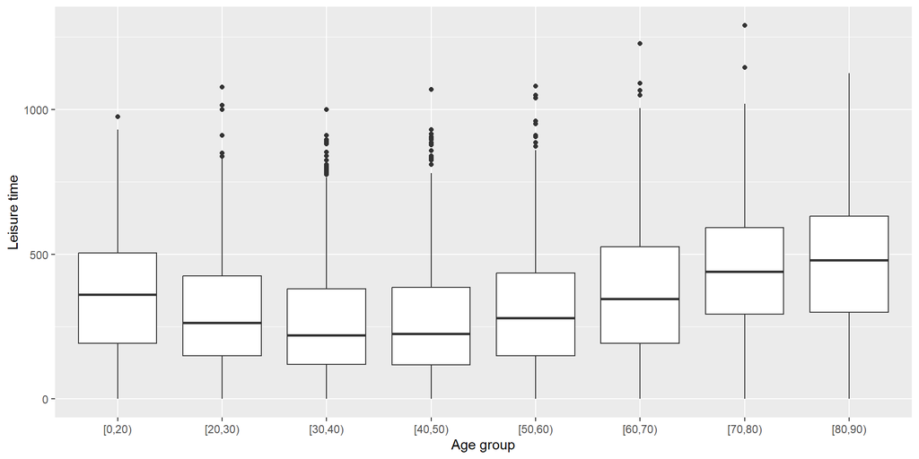

## Some considerations: non-linear effects

If we think there are clear cut points (such as reaching retirement age) we might consider “binning” a continuous variable into a smaller number of values and then treating it as though it were categorical. These could be included on their own or alongside the original variable in one model.

```r
atus<-atus |>
  mutate(age_group = case_when(age <18 ~ "Under 18",
                               age >= 18 & age<65 ~ "Working age",
                               age >=65 ~ "Retirement age"
                               ))

m1<-lm(leisure ~ age, data=atus)
m2<-lm(leisure ~ age_group, data=atus)
m3<-lm(leisure ~ age_group + age, data=atus)
```

**DV: Minutes spent on leisure activities**

|  | (1) | (2) | (3) |
| --- | --- | --- | --- |
| (Intercept) | 171.5 | 435.5 | 323.2 |
|  | [155.0, 188.0] | [426.4, 444.7] | [285.3, 361.2] |
| Age (years) | 3.3 |  | 1.5 |
|  | [3.0, 3.6] |  | [1.0, 2.0] |
| age_group [Retirement age] |  | - | - |
| age_group [Under 18] |  | -100.3 | -12.7 |
|  |  | [-140.4, -60.3] | [-61.9, 36.5] |
| age_group [Working age] |  | -139.6 | -93.6 |
|  |  | [-151.0, -128.2] | [-112.5, -74.7] |
| Num.Obs. | 6146 | 6146 | 6146 |
| R2 | 0.072 | 0.086 | 0.091 |
| R2 Adj. | 0.072 | 0.085 | 0.091 |

## Some considerations: non-linear effects

Alternatively, we might add higher-order polynomial terms to capture more complex continuous relationships:

```r
model_alt<-lm(leisure ~ poly(age, 3), data=atus)
```

**DV: Minutes spent on leisure activities**

|  | (1) |
| --- | --- |
| (Intercept) | 345.1 |
|  | [339.7, 350.4] |
| age [1st degree] | 4747.0 |
|  | [4328.0, 5165.9] |
| age [2nd degree] | 2929.7 |
|  | [2510.8, 3348.7] |
| age [3rd degree] | -1256.4 |
|  | [-1675.3, -837.4] |
| Num.Obs. | 6146 |
| R2 | 0.104 |
| R2 Adj. | 0.104 |

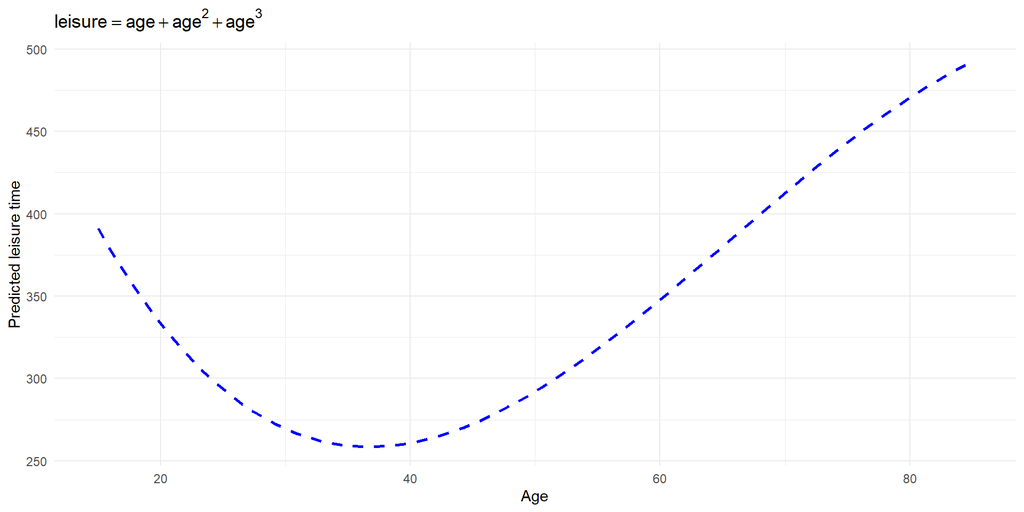

## Some considerations: non-linear effects

- Assuming things are linear (even when they really aren’t) helps you avoid problems with “overfitting”.
- It also simplifies interpretation.
- But remember this is an *assumption* that could be wrong in some situations.

(this comes up frequently when working with survey data because we frequently work with variables that aren’t truly continuous)

## Some considerations: non-continuous outcomes

- Linear regression also assumes the outcome is continuous, but our dependent variable in this case isn’t really.
- Leisure time can never become negative, can’t exceed the number of minutes in a day, and is only reported in whole number increments.

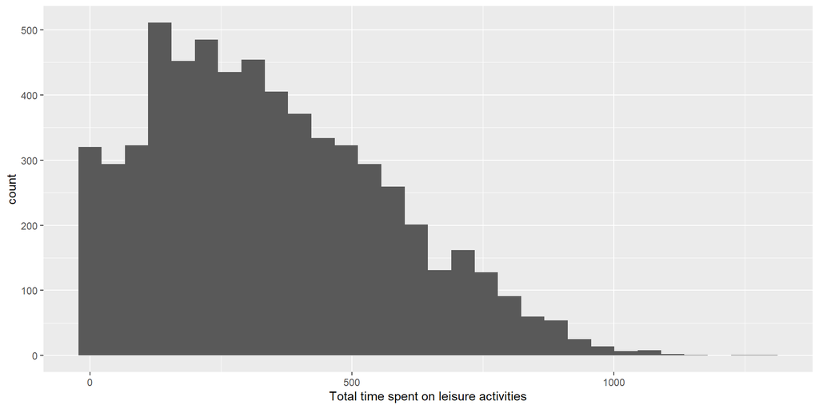

## Some considerations: non-continuous outcomes

In some cases, the outcome variable may be “close enough” to continuous that we don’t care much about these issues, but under some conditions, this may seriously distort regression results.

## Some considerations: non-continuous outcomes

We’ll talk next week about some ways to handle this, but the basic idea requires us to use a more generalized form of a linear model that can effectively model different kinds of outcome distributions.

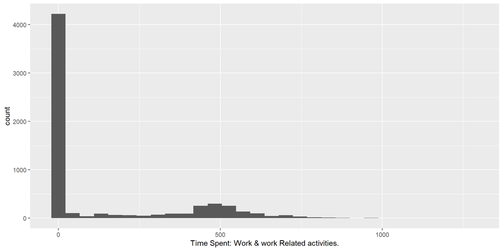

## Example code

[Example code](https://raw.githubusercontent.com/Neilblund/SDSB340-Fall-2026/refs/heads/master/Code/regression_example.R)